# EDA Project

Gina Ge & Christina Fu

2025-10-12

Introduction: This project uses a subset of the 2024 National Health Interview Survey adult questionnaire to explore the relationship between sleep quality and mental health among U.S. adults. The NHIS is a survey conducted annually by the National Center for Health Statistics. From the dataset, we extracted data on sleep quality and mental-health diagonoses and recent care on anxiety, depression, and psychological distress. The motivation for the project is that sleep issues and mental health problems are becoming more widespread and normal common among adults and even teenagers. These issues could severely affect people’s lives. Therefore, understanding how sleep quality correlates with mental health problems might help adults have healthier lives and better efficiency on work.

## Data Cleaning:

```r
data<- read.csv("./adult24.csv")
```

Upload the original dataset consisting 630 variables that provides information about the 2024 NHIS data on participants.

```r
vars <- c(
  "ANXEV_A","DEPEV_A",
  "MHRX_A","MHTHRPY_A","MHTPYNOW_A","MHTHDLY_A","MHTHND_A",
  "SAD_A","NERVOUS_A","RESTLESS_A","HOPELESS_A","EFFORT_A","WORTHLESS_A",
  "CFSEV_A","CFSNOW_A",
  "SLPHOURS_A","SLPREST_A","SLPFLL_A","SLPSTY_A","SLPMED1_A","SLPMED2_A","SLPMED3_A"
)
id_like <- c("SEQN","RespondentID","ID")
vars <- unique(c(intersect(id_like, names(data)), vars))
keep <- intersect(vars, names(data))
out  <- data[ , keep, drop = FALSE]
out_path <- "./adult24_selected.csv"
write.csv(out, out_path, row.names = FALSE)

cat("Saved:", out_path, "\nColumns:", paste(colnames(out), collapse=", "), "\n")
```

```
## Saved: ./adult24_selected.csv
## Columns: ANXEV_A, DEPEV_A, MHRX_A, MHTHRPY_A, MHTPYNOW_A, MHTHDLY_A, MHTHND_A, SAD_A, NERVOUS_A, RESTLESS_A, HOPELESS_A, EFFORT_A, WORTHLESS_A, CFSEV_A, CFSNOW_A, SLPHOURS_A, SLPREST_A, SLPFLL_A, SLPSTY_A, SLPMED1_A, SLPMED2_A, SLPMED3_A
```

```r
data_selected<- read.csv("./adult24_selected.csv")
```

```r
library(dplyr)
library(stringr)

# --- 1) Rename to friendlier snake_case (only if columns exist) ---
data_selected <- data_selected %>%
  rename(
    anxiety_ever       = "ANXEV_A",
    depression_ever       = "DEPEV_A",
    medication_past12     = "MHRX_A",
    therapy_past12 = "MHTHRPY_A",
    therapy_now = "MHTPYNOW_A",
    delay_therapy  = "MHTHDLY_A",
    need_therapy = "MHTHND_A",
    sad_30d        = "SAD_A",
    nervous_30d    = "NERVOUS_A",
    restless_30d   = "RESTLESS_A",
    hopeless_30d   = "HOPELESS_A",
    effort_30d     = "EFFORT_A",
    worthless_30d  = "WORTHLESS_A",
    cfs_ever       ="CFSEV_A",
    cfs_now        = "CFSNOW_A",
    sleep_hours    = "SLPHOURS_A",
    well_rested    = "SLPREST_A",
    trouble_fall_asleep    = "SLPFLL_A",
    trouble_stay_asleep     ="SLPSTY_A",
    prescribe_med_sleep = "SLPMED1_A",
    otc_med_sleep  = "SLPMED2_A",
    mj_sleep   = "SLPMED3_A"
  )
```

```r
if ("sleep_hours" %in% names(data_selected)) {
  data_selected <- data_selected %>%
    mutate(sleep_hours = ifelse(sleep_hours >= 0 & sleep_hours <= 24, sleep_hours, NA_real_))
}
```

Rename the column names so that it is easier for us to understand. Sleep_hours columns sometimes have values like 98. Therefore, we need to set those out of range numbers to NA.

## Data Distributions:

#### Hours Slept Daily

```r
library(ggplot2)

# Summary Statistics
summary(data_selected$sleep_hours)
```

```
##    Min. 1st Qu.  Median    Mean 3rd Qu.    Max.    NA's
##   1.000   6.000   7.000   7.124   8.000  24.000    1126
```

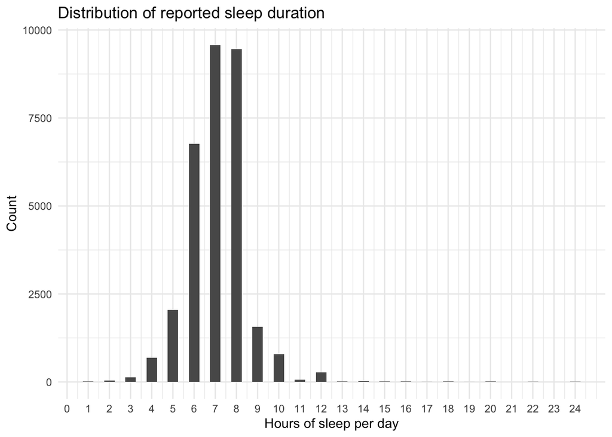

```r
# Histogram
ggplot(data_selected, aes(x = sleep_hours)) +
  geom_histogram(binwidth = 0.5) +
  scale_x_continuous(breaks = seq(0, 24, by = 1)) +
  labs(x = "Hours of sleep per day", y = "Count",
       title = "Distribution of reported sleep duration") +
  theme_minimal()
```

The distribution of hours slept in a 24-hour period appears to be fairly normally distributed with the mean being 7.124 hours and the median being 7 hours.

#### Relevant Mental Health Variables

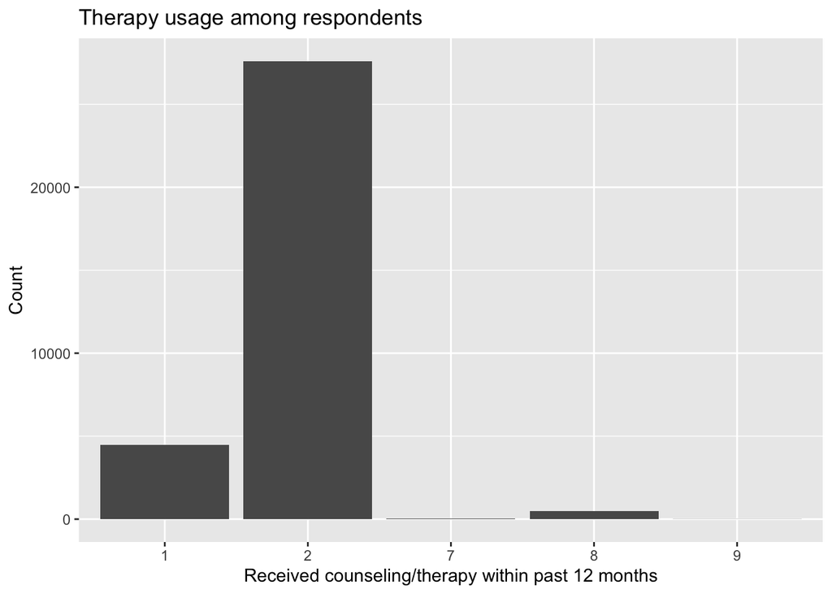

```r
# Therapy/Counseling Received
ggplot(data_selected, aes(x = factor(therapy_past12))) +
  geom_bar() +
  labs(x = "Received counseling/therapy within past 12 months", y = "Count",
       title = "Therapy usage among respondents")
```

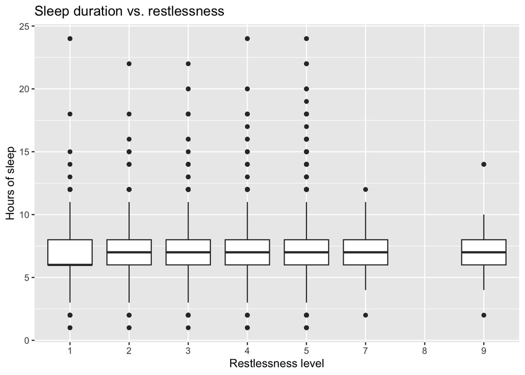

```r
# Restlessness (indicator of psychological distress)
ggplot(data_selected, aes(x = factor(restless_30d), y = sleep_hours)) +
  geom_boxplot() +
  labs(x = "Restlessness level", y = "Hours of sleep",
       title = "Sleep duration vs. restlessness")
```

## Data Analysis:

### Is there a correlation betweeen duration of sleep and restlessness?

```r
spearman_result <-cor.test(data_selected$sleep_hours, data_selected$restless_30d,  method = "spearman")
spearman_result
```

```
##
##  Spearman's rank correlation rho
##
## data:  data_selected$sleep_hours and data_selected$restless_30d
## S = 4.5756e+12, p-value < 2.2e-16
## alternative hypothesis: true rho is not equal to 0
## sample estimates:
##       rho
## 0.1219049
```

[figure not shown]

```r
ggplot(data_selected, aes(x = sleep_hours, y = restless_30d)) +
  geom_point(alpha = 0.4) +
  geom_smooth(method = "lm", se = TRUE, color = "blue") +
  labs(
    title = "Relationship between sleep duration and restlessness",
    x = "Restlessness level",
    y = "Sleep duration (hours)"
  ) +
  theme_minimal()
```

The correlation coefficient between hours slept and restlessness is 0.1219049 and the p-value is less than 2.2e-16. Because the correlation coefficient is close to 0, there is almost no association between the two variables.

### What is the mean sleep for those with anxiety & depression compared to those without?

```r
# Creating a variable that combines depression & anxiety variables
data_selected <- data_selected %>%
  mutate(
    depression_ever = ifelse(depression_ever %in% c(7, 8, 9), NA, depression_ever),
    anxiety_ever = ifelse(anxiety_ever %in% c(7, 8, 9), NA, anxiety_ever),
    mh_group = case_when(
      depression_ever == 1 & anxiety_ever == 1 ~ "Both depression and anxiety",
      depression_ever == 1 & anxiety_ever == 2 ~ "Depression only",
      depression_ever == 2 & anxiety_ever == 1 ~ "Anxiety only",
      depression_ever == 2 & anxiety_ever == 2 ~ "Neither",
      TRUE ~ NA_character_
    )
  )
table(data_selected$mh_group)
```

```
##
##                Anxiety only Both depression and anxiety
##                        1937                        4191
##             Depression only                     Neither
##                        2169                       24265
```

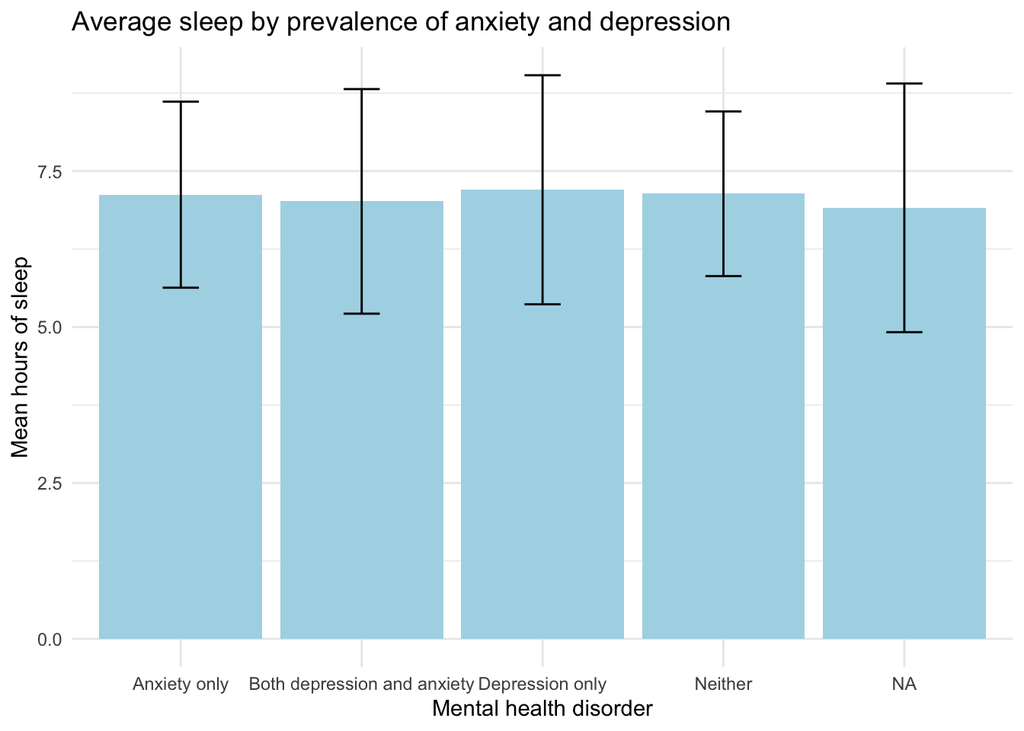

```r
# Visualization
data_selected %>%
  group_by(mh_group) %>%
  summarise(avg_sleep = mean(sleep_hours, na.rm = TRUE), sd_sleep = sd(sleep_hours, na.rm = TRUE), n = n()) %>%
  ggplot(aes(x = mh_group, y = avg_sleep, ymin = avg_sleep - sd_sleep, ymax = avg_sleep + sd_sleep)) +
    geom_col(fill = "lightblue") +
    geom_errorbar(width = 0.2) +
    labs(x = "Mental health disorder", y = "Mean hours of sleep",
         title = "Average sleep by prevalence of anxiety and depression") +
  theme_minimal()
```

```r
# ANOVA test to determine if there is a significant difference in means
anova_result <- aov(sleep_hours ~ mh_group, data = data_selected)
summary(anova_result)
```

```
##                Df Sum Sq Mean Sq F value   Pr(>F)
## mh_group        3     64  21.489   10.36 8.21e-07 ***
## Residuals   31443  65204   2.074
## ---
## Signif. codes:  0 '***' 0.001 '**' 0.01 '*' 0.05 '.' 0.1 ' ' 1
## 1182 observations deleted due to missingness
```

```r
# p-value = 8.21e-07 which suggests a significant difference in means across groups
```